# Lab 6 Demo: Markov Chains (simple version: Dry and Wet)

This demo prepares for Lab 6 using **one** example throughout: the Dry/Wet weather chain of **Chapter 8, Section 8.4.1**,

$$ P=\begin{pmatrix}0.7&0.3\\0.2&0.8\end{pmatrix}\qquad\text{(state order: Dry, Wet)}. $$

With only two states, every number can be checked by hand. The demo covers:

1. the Markov property, and what a transition matrix must satisfy;
2. simulating one step from one uniform number;
3. one path versus the distribution $\pi_n=\pi_0P^n$;
4. the stationary distribution and the ergodic theorem;
5. why days inside one long run are **dependent**, and warm-up;
6. comparing scenarios exactly instead of by simulation.

In the lab you write **general** versions of these ideas for a three-state chain: the boxes marked *Your turn in the lab* tell you what to think about.

| Demo | Theory | Lab 6 part |
| --- | --- | --- |
| 1 | Transition matrix, validity checks | A |
| 2 | One step from one uniform; one path | B |
| 3 | Many paths versus $\pi_0P^n$ | B |
| 4 | Matrix powers, stationary distribution, one long path | C |
| 5 | Dependence and warm-up | D |
| 6 | Exact scenario comparison | E |
| 7 | Writing a recommendation | Recommendation and reflection |

```python
import numpy as np
import pandas as pd
import matplotlib.pyplot as plt

DEMO_SEED = 6901
```

## Theory 1: The Markov property (Chapter 8, Section 8.3)

Let $X_n=0$ if day $n$ is dry and $X_n=1$ if it is wet. The sequence $X_0,X_1,X_2,\dots$ is a **Markov chain** if

$$ \mathbb P(X_{n+1}=j\mid X_n=i,\ X_{n-1},\dots,X_0)=\mathbb P(X_{n+1}=j\mid X_n=i)=p_{ij}. $$

**Given today, the past adds nothing** for predicting tomorrow. The $p_{ij}$ form the **transition matrix** $P$: row $i$ is "from $i$", column $j$ is "to $j$".

This is a claim about the **model**, not about reality. Real weather has a longer memory; if that matters, a better model enlarges the state (for example "wet for two days in a row" as its own state).

**Question:** Is each process plausibly Markov with the state given?

1. Tomorrow's weather, with state = today's weather.
2. Your final exam mark, with state = your last quiz mark only.
3. The number of customers in a shop at the end of each minute, with random arrivals and service completions (Chapter 8, Section 8.8).

## Demo 1: The Dry/Wet transition matrix

Chapter 8 assumes $\mathbb P(\text{Dry tomorrow}\mid\text{Dry today})=0.7$ and $\mathbb P(\text{Wet tomorrow}\mid\text{Wet today})=0.8$. Each row must be a probability distribution, so the missing entries are $0.3$ and $0.2$.

| From / To | Dry | Wet |
| --- | --- | --- |
| Dry | 0.7 | 0.3 |
| Wet | 0.2 | 0.8 |

A valid transition matrix is **square**, and every row is a probability distribution:

$$ 0\le p_{ij}\le1\quad\text{for all } i,j,\qquad \sum_j p_{ij}=1\quad\text{for every row } i . $$

These are **two separate conditions**: a row can sum to 1 and still contain a negative number.

```python
weather = np.array(["Dry", "Wet"])
P = np.array([
    [0.7, 0.3],
    [0.2, 0.8],
])
pd.DataFrame(P, index=weather, columns=weather)     # rows = today, columns = tomorrow
```

|  | Dry | Wet |
| --- | --- | --- |
| Dry | 0.7 | 0.3 |
| Wet | 0.2 | 0.8 |

```python
# NEW: .shape = (number of rows, number of columns)
print("shape:", P.shape)
for i, name in enumerate(weather):                  # NEW: enumerate gives (position, item) pairs
    row = P[i]
    print(f"{name} row: sum = {row.sum():.2f}, smallest = {row.min():.2f}, largest = {row.max():.2f}")

broken_row = np.array([1.1, -0.1])                  # passes one check, fails the other
print(f"broken row: sum = {broken_row.sum():.2f}, smallest = {broken_row.min():.2f}")
```

```
shape: (2, 2)
Dry row: sum = 1.00, smallest = 0.30, largest = 0.70
Wet row: sum = 1.00, smallest = 0.20, largest = 0.80
broken row: sum = 1.00, smallest = -0.10
```

The broken row sums to exactly 1, but $-0.1$ and $1.1$ are not probabilities.

> **Your turn in the lab.** Part A asks for one function that returns `True` or `False` for **any** matrix. Printing rows is fine for looking, but your function must decide automatically. Which NumPy operations test a condition for *every* entry, or *every* row, at once? Remember from Lab 3 that a sum of floats can give `0.9999999999` instead of 1, so an exact `== 1` comparison is risky.

## Theory 2: One step from one uniform number (Chapter 8, Section 8.4.3)

From state $i$, draw $U\sim\mathrm{Uniform}(0,1)$ and split $[0,1]$ into pieces whose lengths are the probabilities in row $i$. With two states there is one cut point, $p_{i0}$:

- if $U\le p_{i0}$, tomorrow is **Dry** (state 0);
- otherwise tomorrow is **Wet** (state 1).

| Today | cut point $p_{i0}$ | Dry if | Wet if |
| --- | --- | --- | --- |
| Dry | 0.7 | $U\le0.7$ | $U>0.7$ |
| Wet | 0.2 | $U\le0.2$ | $U>0.2$ |

This is the **discrete inverse-transform method** of Lab 3: each piece has length equal to its probability.

**Question:** Start Dry. The uniforms are $0.62,\ 0.85,\ 0.15,\ 0.95$. Predict the next four days, then check with the code below.

## Demo 2: Simulate the weather

### Step 1 — the one-step rule for two states

```python
def next_day(matrix, today, u):
    # Next state of a TWO-state chain: Dry (0) if u <= p_{today,0}, otherwise Wet (1).
    if u <= matrix[today, 0]:
        return 0
    else:
        return 1


today = 0                                          # check the question above: start Dry
for u in [0.62, 0.85, 0.15, 0.95]:
    today = next_day(P, today, u)
    print(f"u = {u:.2f} -> {weather[today]}")
```

```
u = 0.62 -> Dry
u = 0.85 -> Wet
u = 0.15 -> Dry
u = 0.95 -> Wet
```

> **Your turn in the lab.** Lab 6 has **three** states, so one cut point is not enough. Part B asks for `sample_state(probabilities, u)` that works for a row of **any length**: build the cut points as running totals of the row, and return the first cut point at or above $U$. Which NumPy function from Lab 3 does that in one call, and which `side` gives "at or above"?

### Step 2 — fourteen days with a loop

```python
rng = np.random.default_rng(DEMO_SEED)
n_days = 14
today = 0                                          # start Dry
days = [today]                                     # day 0 is recorded too
for day in range(n_days):
    today = next_day(P, today, rng.random())
    days.append(today)

print(len(days), "recorded days")
# NEW: " -> ".join(list of text) glues the text together
print(" -> ".join(weather[days]))
```

```
15 recorded days
Dry -> Dry -> Dry -> Dry -> Dry -> Dry -> Dry -> Dry -> Dry -> Wet -> Wet -> Wet -> Dry -> Dry -> Dry
```

**Question:** Why does a 14-day simulation record 15 states?

**Note.** One path is one random story. Another seed gives another story.

> **Your turn in the lab.** Part B asks you to package a path into `simulate_path(matrix, start, n_steps, rng)`. What goes in the list first? Where is the uniform drawn? Why must the generator be an **argument** rather than created inside the function (Lab 4)?

## Theory 3: The distribution of a chain (Chapter 8, Section 8.5)

A forecaster wants **probabilities**, not one story. Write the distribution on day $n$ as a row vector $\pi_n=(\mathbb P(X_n=\text{Dry}),\ \mathbb P(X_n=\text{Wet}))$. Conditioning on today's state,

$$ \pi_{n+1}=\pi_nP,\qquad\text{so}\qquad\pi_n=\pi_0P^n , $$

and $(P^n)_{ij}=\mathbb P(X_n=j\mid X_0=i)$. Chapter 8's two-step example:

$$ P^2=\begin{pmatrix}0.7&0.3\\0.2&0.8\end{pmatrix}\begin{pmatrix}0.7&0.3\\0.2&0.8\end{pmatrix}=\begin{pmatrix}0.55&0.45\\0.30&0.70\end{pmatrix}, \qquad \mathbb P(X_2=\text{Dry}\mid X_0=\text{Wet})=0.30 . $$

Once $\pi_0$ and $P$ are fixed, $\pi_n$ is **not random**. Simulating $m$ independent paths and counting states reproduces $\pi_0P^n$ up to sampling error, about $\sqrt{p(1-p)/m}$.

## Demo 3: 500 towns versus the exact distribution

Imagine 500 towns that all start Dry and have independent weather.

```python
# Restart the stream: town 1 repeats Demo 2's path exactly.
rng = np.random.default_rng(DEMO_SEED)
n_towns = 500
# NEW: np.zeros((rows, columns), dtype=int) is a table of zeros; column 0 (day 0) stays 0 = Dry
towns = np.zeros((n_towns, n_days + 1), dtype=int)
for town in range(n_towns):
    today = 0
    for day in range(1, n_days + 1):
        today = next_day(P, today, rng.random())
        towns[town, day] = today
towns[:3]                                          # first three towns
```

```
array([[0, 0, 0, 0, 0, 0, 0, 0, 0, 1, 1, 1, 0, 0, 0],
       [0, 0, 0, 1, 0, 0, 0, 1, 0, 1, 1, 1, 1, 1, 1],
       [0, 0, 1, 1, 1, 1, 1, 0, 0, 0, 0, 0, 0, 0, 0]])
```

```python
pi_n = np.array([1.0, 0.0])                        # exact distribution, day 0: certainly Dry
exact = [pi_n]
for day in range(1, n_days + 1):
    pi_n = pi_n @ P                                # NEW: @ multiplies a row vector by a matrix
    exact.append(pi_n)
exact = np.array(exact)

simulated_wet = towns.mean(axis=0)                 # NEW: axis=0 averages DOWN each column: fraction Wet on each day

pd.DataFrame({"500 towns: fraction Wet": simulated_wet, "exact P(Wet)": exact[:, 1]}).loc[[1, 2, 3, 14]].round(4)
```

|  | 500 towns: fraction Wet | exact P(Wet) |
| --- | --- | --- |
| 1 | 0.292 | 0.300 |
| 2 | 0.452 | 0.450 |
| 3 | 0.506 | 0.525 |
| 14 | 0.628 | 0.600 |

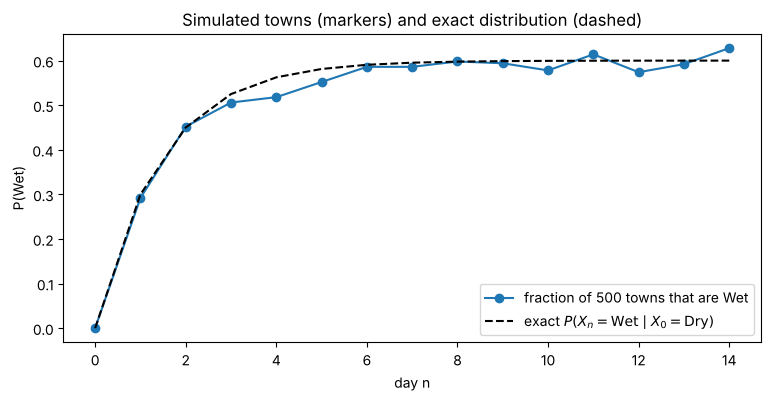

```python
fig, ax = plt.subplots(figsize=(9, 4))
ax.plot(range(n_days + 1), simulated_wet, marker="o", label="fraction of 500 towns that are Wet")
ax.plot(range(n_days + 1), exact[:, 1], color="black", linestyle="--", label=r"exact $P(X_n=\mathrm{Wet}\mid X_0=\mathrm{Dry})$")
ax.set_xlabel("day n")
ax.set_ylabel("P(Wet)")
ax.set_title("Simulated towns (markers) and exact distribution (dashed)")
ax.legend()
plt.show()
```

**Note.** Because Wet is coded 1, the fraction of towns that are Wet is just the mean of each column. Day 2's exact value is 0.45, the (Dry, Wet) entry of $P^2$ above. For this chain there is even a formula: starting Dry, $\mathbb P(X_n=\text{Wet})=0.6\,(1-0.5^n)$.

**Question:** On day 14 the simulated Wet share is 0.628 against the exact 0.600. Is the simulation wrong?

> **Your turn in the lab.** In Part B every customer starts from a **random** state drawn from $\pi_0$, not from a fixed state. How can the same one-step idea draw the starting state? For the exact forecast you need $\pi_0P^n$ for every $n=0,\dots,12$: repeated multiplication as above, or `np.linalg.matrix_power(P, n)` for each $n$. Which is easier?

## Theory 4: The stationary distribution (Chapter 8, Section 8.7)

A probability vector $\pi$ is **stationary** if

$$ \pi=\pi P,\qquad \sum_j\pi_j=1 . $$

If today's distribution is $\pi$, tomorrow's is also $\pi$.

**Chapter 8's example, by hand.** With $\pi=(\pi_D,\pi_W)$, the first component of $\pi=\pi P$ gives

$$ \pi_D=0.7\pi_D+0.2\pi_W\ \Longrightarrow\ 0.3\pi_D=0.2\pi_W . $$

The second component gives $\pi_W=0.3\pi_D+0.8\pi_W$, that is $0.2\pi_W=0.3\pi_D$: **the same equation**. One equation of $\pi=\pi P$ is always redundant, because every row of $P$ sums to 1. The condition $\pi_D+\pi_W=1$ is what pins down the answer:

$$ \pi_D=\tfrac25=0.4,\qquad \pi_W=\tfrac35=0.6 . $$

In the long run about 60% of days are wet. (Read $0.3\pi_D=0.2\pi_W$ as a balance: in the long run, the flow from Dry to Wet equals the flow from Wet to Dry.)

**Ergodic theorem for finite chains.** If the chain is **irreducible** (every state can reach every other) and **aperiodic** (for example some $p_{ii}>0$), then

1. there is exactly one stationary distribution $\pi$;
2. $(P^n)_{ij}\to\pi_j$ for every starting state $i$: **the rows of $P^n$ become identical**;
3. the fraction of time **one long path** spends in state $j$ converges to $\pi_j$.

Both conditions hold here: Dry and Wet reach each other in one step, and $p_{DD}>0$.

## Demo 4: Long-run weather: exact and simulated

### Way 1 — matrix powers

```python
for n in [1, 2, 5, 10, 20]:
    # NEW: np.linalg.matrix_power(P, n) = P^n
    print(f"P^{n} =\n{np.round(np.linalg.matrix_power(P, n), 4)}\n")
```

```
P^1 =
[[0.7 0.3]
 [0.2 0.8]]

P^2 =
[[0.55 0.45]
 [0.3  0.7 ]]

P^5 =
[[0.4188 0.5812]
 [0.3875 0.6125]]

P^10 =
[[0.4006 0.5994]
 [0.3996 0.6004]]

P^20 =
[[0.4 0.6]
 [0.4 0.6]]
```

### Way 2 — simulation: one long path, or many runs

Chapter 8, Section 8.7.1: start Dry, discard a warm-up of 100 days, then count the wet days in the next 10,000 days. The table also shows the 500 towns of Demo 3 on day 14.

```python
rng = np.random.default_rng(DEMO_SEED)
warm_up, n_long = 100, 10_000
today = 0                                          # start Dry
for day in range(warm_up):                         # warm-up: step, but do not count
    today = next_day(P, today, rng.random())

wet_count = 0
for day in range(n_long):
    today = next_day(P, today, rng.random())
    if today == 1:
        wet_count += 1                             # NEW: x += 1 means x = x + 1

pd.DataFrame({
    "P(Wet)": [np.linalg.matrix_power(P, 20)[0, 1], 3 / 5, wet_count / n_long, simulated_wet[n_days]],
}, index=["row Dry of P^20", "solved by hand: 3/5", "one long path (10,000 days)", "500 towns on day 14 (Demo 3)"]).round(4)
```

|  | P(Wet) |
| --- | --- |
| row Dry of P^20 | 0.6000 |
| solved by hand: 3/5 | 0.6000 |
| one long path (10,000 days) | 0.5961 |
| 500 towns on day 14 (Demo 3) | 0.6280 |

**Note.** The rows of $P^n$ agree to four decimals by $n=20$, at $(0.4, 0.6)$: exactly the hand solution. They settle fast because the gap shrinks like $0.5^n$ (0.5 is $P$'s second eigenvalue, $1-p_{DW}-p_{WD}$). The long path gives about 0.596: close, but random. Both simulations agree with $\pi$ **approximately**: the long path is **one** run averaged over time (ergodic theorem); the towns are **many** independent runs on one late day (law of large numbers).

> **Your turn in the lab.** Part C adds a general solver, `stationary_distribution(matrix)`, for a **three**-state chain: the lab sheet gives the linear system, with one equation replaced by $\sum_j\pi_j=1$. Test your function on this $P$ first: it should return $(0.4, 0.6)$. NumPy tools: `matrix.T` (transpose) and `np.eye(n)` (the n × n identity matrix).

## Theory 5: Dependence and warm-up (Chapter 8, Section 8.8)

**Days inside one run are dependent.** In Labs 4 and 5 each replication was independent, so $\bar X\pm1.96\,s/\sqrt n$ worked. Inside one run of the weather chain, today strongly predicts tomorrow: wet days come in clumps. For a stationary sequence with variance $\sigma^2$ and lag-$k$ correlations $\rho_k$ (Chapter 9),

$$ \operatorname{Var}(\bar X_N)=\frac{\sigma^2}{N}\left[1+2\sum_{k=1}^{N-1}\Bigl(1-\frac kN\Bigr)\rho_k\right]. $$

With positive correlations the bracket is larger than 1, so the naive $s/\sqrt N$ from one run is **too small**.

**Runs remember their start.** Starting Dry, $\mathbb P(X_n=\text{Wet})=0.6(1-0.5^n)$ reaches 0.6 only gradually, so early days over-represent Dry. Discarding the first part of each run is a **warm-up**.

**The honest fix.** Run **independent replications**, take one number per run, and use the spread **across runs**.

## Demo 5: 200 runs of 1,000 days

Target: the long-run fraction of wet days, $\pi_W=0.6$. All runs start Dry; one generator is used for all runs (each run continues the stream). Each row of the table is one run; each column is one day.

```python
rng = np.random.default_rng(DEMO_SEED)
n_runs, n_days_run = 200, 1000
runs = np.zeros((n_runs, n_days_run + 1), dtype=int)   # all runs start Dry: column 0 stays 0
for r in range(n_runs):
    today = 0
    for day in range(1, n_days_run + 1):
        today = next_day(P, today, rng.random())
        runs[r, day] = today

wet_days = runs[:, 1:]                               # drop day 0
# NEW: axis=1 averages ACROSS each row: one wet fraction per run
run_fractions = wet_days.mean(axis=1)
naive_ses = wet_days.std(axis=1, ddof=1) / np.sqrt(n_days_run)

pd.Series({
    "exact pi_W = 3/5": 3 / 5,
    "run 1: fraction of wet days": run_fractions[0],
    # NEW: np.corrcoef(x, y)[0, 1] is the correlation of x and y; here day d against day d + 1
    "run 1: correlation of consecutive days": np.corrcoef(wet_days[0, :-1], wet_days[0, 1:])[0, 1],
    "all 200,000 days pooled: fraction wet": wet_days.mean(),
    "day 1000 of the 200 runs: fraction wet": wet_days[:, -1].mean(),
    "typical naive SE s/sqrt(N) from one run": naive_ses.mean(),
    "actual SD of the 200 run fractions": run_fractions.std(ddof=1),
}).round(4)
```

```
exact pi_W = 3/5                           0.6000
run 1: fraction of wet days                0.5700
run 1: correlation of consecutive days     0.5283
all 200,000 days pooled: fraction wet      0.6016
day 1000 of the 200 runs: fraction wet     0.6200
typical naive SE s/sqrt(N) from one run    0.0155
actual SD of the 200 run fractions         0.0278
dtype: float64
```

**Note.** Many runs reproduce $\pi_W=0.6$ approximately, both pooled over all days (0.602) and across runs on day 1000 (0.620, from only 200 values). But consecutive days in a run are correlated (about 0.53 in run 1), and the naive standard error from one run (about 0.016) is far smaller than the real spread across runs (about 0.028). For this chain the lag-$k$ correlation is exactly $0.5^k$, so the bracket in Theory 5 is close to $\frac{1+0.5}{1-0.5}=3$ and the true SE is about $\sqrt3\approx1.7$ times the naive one: 1,000 dependent days carry about as much information as 1,000/3 ≈ 330 independent days. Longer runs do not fix this; the factor is the same whatever $N$ is.

### The warm-up

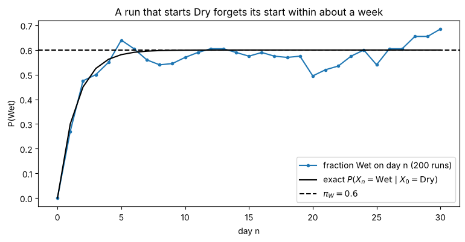

```python
simulated_curve = runs[:, :31].mean(axis=0)          # fraction of the 200 runs that are Wet on day n

pi_n = np.array([1.0, 0.0])                           # exact: start Dry
exact_curve = [pi_n[1]]
for day in range(1, 31):
    pi_n = pi_n @ P
    exact_curve.append(pi_n[1])

fig, ax = plt.subplots(figsize=(9, 4))
ax.plot(range(31), simulated_curve, marker=".", label="fraction Wet on day n (200 runs)")
ax.plot(range(31), exact_curve, color="black", label=r"exact $P(X_n=\mathrm{Wet}\mid X_0=\mathrm{Dry})$")
ax.axhline(0.6, color="black", linestyle="--", label=r"$\pi_W=0.6$")
ax.set_xlabel("day n")
ax.set_ylabel("P(Wet)")
ax.set_title("A run that starts Dry forgets its start within about a week")
ax.legend()
plt.show()
```

**Note.** The exact curve is $0.6(1-0.5^n)$: 0, 0.30, 0.45, 0.525 on days 0–3, and within 0.005 of 0.6 by day 7. So the warm-up bias over 1,000 days is negligible here.

> **Your turn in the lab.** Part D repeats this experiment for the slotted coffee-shop queue, a **four**-state chain, so the two-state rule no longer works. Which of your own Part A–C functions can produce each run? For each run you need two numbers: the run average and the naive $s/\sqrt N$ from that run alone.

## Demo 6: A wetter-climate scenario, calculated exactly

A climate report suggests that dry days turn wet more often and wet spells last longer:

| From / To | Dry | Wet |
| --- | --- | --- |
| Dry | 0.6 | 0.4 |
| Wet | 0.1 | 0.9 |

The distribution after $n$ days and the long-run mix are **exact** functions of the matrix, so no simulation is needed: simulate when necessary; calculate when the model gives the answer. (For a two-state chain the long run even has a formula: $\pi_W=p_{DW}/(p_{DW}+p_{WD})$, from the balance in Theory 4.)

```python
P_wet = np.array([[0.6, 0.4],
                  [0.1, 0.9]])

rows = []
for name, matrix in [("Current", P), ("Wetter", P_wet)]:
    pi_n = np.array([1.0, 0.0])                        # start Dry
    for day in range(1, 8):
        pi_n = pi_n @ matrix
        if day in [1, 3, 7]:                           # NEW: "x in [list]" tests membership
            rows.append({"climate": name, "horizon": f"day {day}", "P(Wet)": pi_n[1]})
    rows.append({"climate": name, "horizon": "long run (row of matrix^100)",
                 "P(Wet)": np.linalg.matrix_power(matrix, 100)[0, 1]})
pd.DataFrame(rows).set_index(["climate", "horizon"]).round(4)
```

| climate | horizon | P(Wet) |
| --- | --- | --- |
| Current | day 1 | 0.3000 |
|  | day 3 | 0.5250 |
|  | day 7 | 0.5953 |
|  | long run (row of matrix^100) | 0.6000 |
| Wetter | day 1 | 0.4000 |
|  | day 3 | 0.7000 |
|  | day 7 | 0.7938 |
|  | long run (row of matrix^100) | 0.8000 |

### Which change matters most? Change one row at a time

```python
one_row = [{"row changed": "none", "long-run P(Wet)": np.linalg.matrix_power(P, 100)[0, 1]}]
for r, name in enumerate(weather):
    changed = P.copy()                                 # .copy(): never change P itself (Lab 4)
    changed[r] = P_wet[r]
    one_row.append({"row changed": name, "long-run P(Wet)": np.linalg.matrix_power(changed, 100)[0, 1]})
one_row.append({"row changed": "both", "long-run P(Wet)": np.linalg.matrix_power(P_wet, 100)[0, 1]})
pd.DataFrame(one_row).set_index("row changed").round(4)
```

| row changed | long-run P(Wet) |
| --- | --- |
| none | 0.6000 |
| Dry | 0.6667 |
| Wet | 0.7500 |
| both | 0.8000 |

**Note.** The long-run wet share rises from 0.6 to 0.8. One row at a time: changing the Dry row (dry days turn wet more often, 0.3 → 0.4) gives about 0.667; changing the Wet row (wet spells last longer, 0.8 → 0.9) gives 0.75. Check both with $\pi_W=p_{DW}/(p_{DW}+p_{WD})$: $0.4/0.6$ and $0.3/0.4$. Making wet spells more persistent is the stronger single lever here.

This does not show that the climate will get wetter. It shows what the matrix implies; the matrix itself is an assumption that needs data.

> **Your turn in the lab.** Part E asks for `distribution_after(matrix, initial, n)` and compares the loyalty card at several horizons and in the long run. You have seen two ways to get $\pi_0P^n$ (repeated multiplication, or one matrix power) and two ways to get the long run (a high power, or your Part C solver). Which will you use, and why?

## Demo 7: A strong interpretation

> Under the wetter-climate matrix, the long-run share of wet days would rise from 60% to about 80%, and most of the change appears within a week of the new pattern starting. The larger single driver is that wet spells last longer. These figures are exact consequences of the assumed matrix, not forecasts: the matrix should be estimated from observed day-to-day transitions before it is used for planning. For any uncertainty statement based on simulating one long weather record, consecutive days are dependent, so the standard error must come from independent runs, not from $s/\sqrt N$ within one run.

A strong recommendation connects: what the model predicts, with numbers; how quickly the effect appears; which assumption drives it; whether the result is exact or simulated, and how its uncertainty was measured; what evidence is needed next.

## Final theory map

**Markov property:** $\mathbb P(X_{n+1}=j\mid X_n=i,\text{past})=p_{ij}$.

**Valid matrix:** square, $0\le p_{ij}\le1$, and every row sums to 1.

**One step:** with two states, Dry if $U\le p_{i0}$, otherwise Wet; in general, the first cut point of the cumulative row at or above $U$.

**Distribution:** $\pi_{n+1}=\pi_nP$, so $\pi_n=\pi_0P^n$; $(P^n)_{ij}=\mathbb P(X_n=j\mid X_0=i)$.

**Stationary:** $\pi=\pi P$, $\sum\pi_j=1$ (one equation of $\pi=\pi P$ is redundant); for Dry/Wet, $\pi=(0.4,0.6)$. For an irreducible, aperiodic finite chain the rows of $P^n\to\pi$ and time fractions $\to\pi$.

**Output analysis:** days inside one run are dependent ($s/\sqrt N$ is too small); runs remember their start (warm-up); use independent replications.

| This … | … is not this |
| --- | --- |
| one path | the distribution $\pi_0P^n$ |
| rows summing to 1 | a valid matrix (entries must also be in $[0,1]$) |
| a long path's time fractions (random) | the stationary distribution (exact) |
| $s/\sqrt N$ from one run | the real uncertainty of the run average |
| an exact scenario calculation | a simulation estimate |
| a scenario matrix | evidence about the real system |

## What you will build yourself in Lab 6

| Demo (two states) | Lab 6 (three or four states, you write it) |
| --- | --- |
| printing each row's sum and smallest entry | `validate_transition_matrix(matrix)` for any matrix |
| `next_day`: one cut point, one `if` | `sample_state(probabilities, u)` for any number of states |
| a 14-day loop, 500 towns from Dry | `simulate_path(matrix, start, n_steps, rng)` and customers from a random start |
| $\pi$ solved by hand; matrix powers; one long path | `stationary_distribution(matrix)`, solving the equations |
| 200 runs with the two-state rule | runs of the four-state slotted queue with your own functions |

Python tools you have now seen: `@`, `np.linalg.matrix_power`, `axis=0` / `axis=1`, `np.corrcoef`, `enumerate`, `.shape`.

## Common errors

- Checking only the row sums, not the bounds or the shape.
- Comparing a sum of floats with `== 1`.
- Using the Dry row's cut point after moving to Wet.
- Creating a new generator inside a path function, which repeats the same path every time.
- Multiplying in the wrong order (`P @ pi0` instead of `pi0 @ P`).
- Solving $\pi=\pi P$ without the condition $\sum\pi_j=1$.
- Treating the days inside one run as independent observations.
- Calling a scenario matrix "evidence".